# The Simpsons Viewership Analysis

## 1 Show Description

### 1.1 Overview

*The Simpsons* is an American animated sitcom created by Matt Groening that premiered on December 17, 1989. The series follows the satirical adventures of the Simpson family - Homer, Marge, Bart, Lisa, and Maggie - in the fictional town of Springfield. As the longest-running American scripted primetime television series, it has become a cultural phenomenon.

### 1.2 Cultural Impact

- First aired: December 17, 1989
- Network: Fox
- Awards: 35 Primetime Emmy Awards
- Cultural references: Over 10,000 pop culture references made
- Language impact: Popularized phrases like “D’oh!” and “Excellent!”

### 1.3 Characters

Table 1: Main Cast

(a) Original Cast

|  | Character | Voice Actor | First Appearance |
| --- | --- | --- | --- |
| 1 | Homer | Dan Castellaneta | 1987 |
| 2 | Marge | Julie Kavner | 1987 |
| 3 | Bart | Nancy Cartwright | 1987 |
| 4 | Lisa | Yeardley Smith | 1987 |
| 5 | Maggie | Various | 1989 |

(b) Supporting Cast

|  | Character | Voice Actor | First Appearance |
| --- | --- | --- | --- |
| 1 | Mr. Burns | Harry Shearer | 1990 |
| 2 | Krusty | Dan Castellaneta | 1989 |
| 3 | Ned Flanders | Harry Shearer | 1990 |
| 4 | Principal Skinner | Harry Shearer | 1990 |

## 2 Logo representation

[figure not shown]

Figure 1: The Simpsons Official Logo

## 3 Basic Statistics

Table 2: Key Statistics

| Metric | Value |
| --- | --- |
| Seasons | 36 |
| Episodes | 782 |
| Peak Viewership | 33.6 million (S3E1, 1991) |
| Current Viewership | 1.2 million (S35) |
| IMDb Rating | 8.6/10 |
| Longest Running Scripted Show | Yes (since 1997) |
| Countries Aired | 100+ |

## 4 Viewership Trend

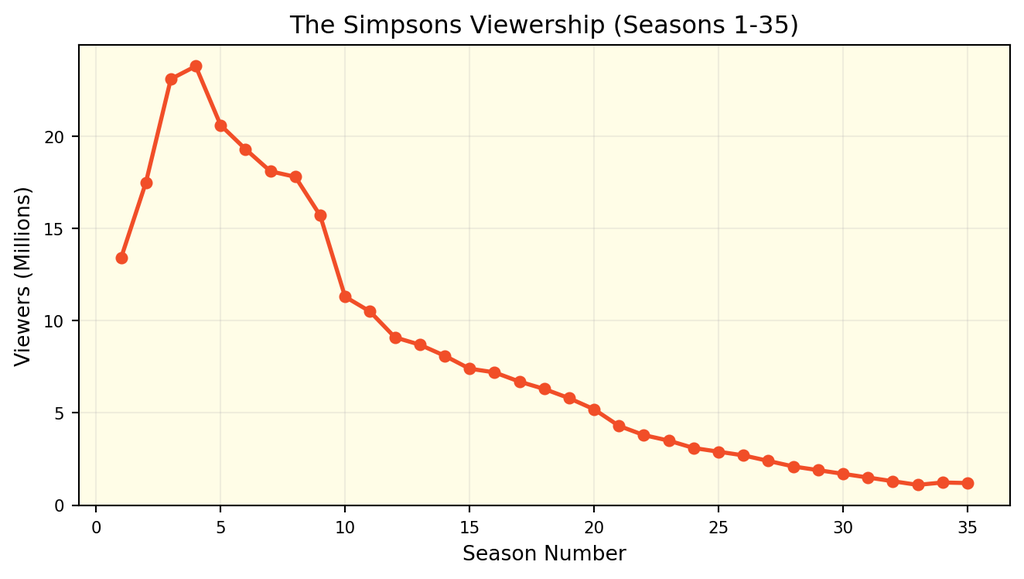

(a) Average Seasonal Viewership (Millions)

| Season | Avg Viewers (millions) | Change (%) |
| --- | --- | --- |
| 1 | 13.4 | 0.0% |
| 2 | 17.5 | 30.6% |
| 3 | 23.1 | 32.0% |
| 4 | 23.8 | 3.0% |
| 5 | 20.6 | -13.4% |
| 6 | 19.3 | -6.3% |
| 7 | 18.1 | -6.2% |
| 8 | 17.8 | -1.7% |
| 9 | 15.7 | -11.8% |
| 10 | 11.3 | -28.0% |
| 11 | 10.5 | -7.1% |
| 12 | 9.1 | -13.3% |
| 13 | 8.7 | -4.4% |
| 14 | 8.1 | -6.9% |
| 15 | 7.4 | -8.6% |
| 16 | 7.2 | -2.7% |
| 17 | 6.7 | -6.9% |
| 18 | 6.3 | -6.0% |
| 19 | 5.8 | -7.9% |
| 20 | 5.2 | -10.3% |
| 21 | 4.3 | -17.3% |
| 22 | 3.8 | -11.6% |
| 23 | 3.5 | -7.9% |
| 24 | 3.1 | -11.4% |
| 25 | 2.9 | -6.5% |
| 26 | 2.7 | -6.9% |
| 27 | 2.4 | -11.1% |
| 28 | 2.1 | -12.5% |
| 29 | 1.9 | -9.5% |
| 30 | 1.7 | -10.5% |
| 31 | 1.5 | -11.8% |
| 32 | 1.3 | -13.3% |
| 33 | 1.1 | -15.4% |
| 34 | 1.2 | 11.8% |
| 35 | 1.2 | -2.4% |

(b)

Figure 2

## 5 Yearly Changes

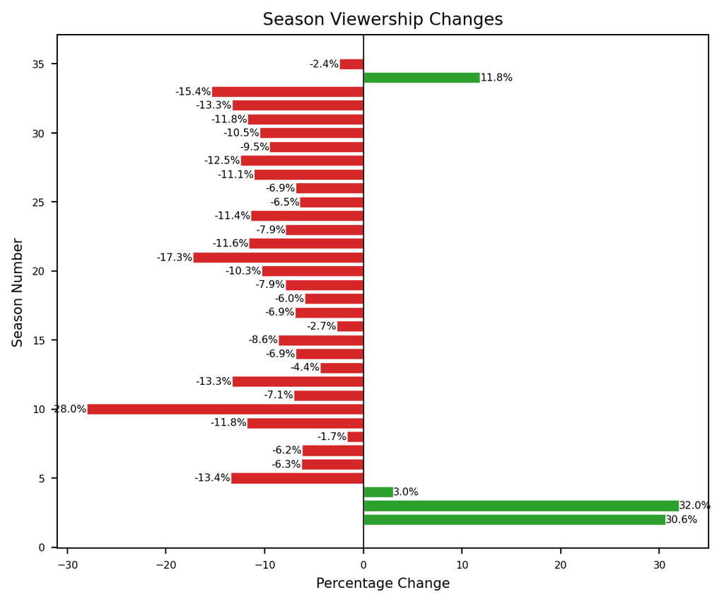

Figure 3: Season-to-Season Viewership Changes (%)

## 6 Trend Analysis

The viewership data reveals several significant patterns in *The Simpsons’* audience trends over its 35-season run:

**Critical Decline Period**

The most substantial viewership drop occurred between **Seasons 9-10** (1997-99), with a **28.0% decrease** in average viewership. This coincided with: - Increased competition from other animated series - Changes in writing staff - Shifting audience preferences

**Modern Era Stability**

In recent seasons (31-35), the show has stabilized with: - An average of **1.3 million viewers** - Seasonal fluctuations of **±15.4%**  
While significantly lower than peak numbers, this demonstrates the series maintains a loyal core audience.

**Long-Term Trend**

The overall **91.0% decline** from Season 1 to Season 35 reflects both: 1. Natural aging of a long-running series 2. Fundamental changes in television viewing habits 3. Increased competition in the streaming era

*Despite these declines, The Simpsons remains culturally significant and profitable through syndication and streaming deals.*

## References

### Data Sources

1. [The Simpsons Episode Guide](https://en.wikipedia.org/wiki/List_of_The_Simpsons_episodes), Wikipedia
2. [IMDb Episode Ratings](https://www.imdb.com/title/tt0096697/episodes), IMDb

### Image Credits

- Logo: [Fair use via Wikimedia](https://upload.wikimedia.org/wikipedia/commons/thumb/b/b7/The_logo_simpsons_yellow.png/1200px-The_logo_simpsons_yellow.png?20210413044310)